# B2B Sales & Inventory Analysis using Python

**Project By:** Rahul Solanki

## Project Objective

This project analyzes B2B Sales & Inventory data using Python, Pandas, and Matplotlib. The objective is to clean the dataset, perform exploratory data analysis (EDA), identify top products, and visualize key business insights.

## Import Libraries

Import the required Python libraries for data analysis and visualization.

```python
# Import Liabraries

import pandas as pd
import matplotlib.pyplot as plt
```

## Load Dataset

Load the B2B Sales & Inventory dataset into a Pandas DataFrame.

```python
# Load Dataset

df = pd.read_csv("B2B Sales & Inventory Dashboard - Sheet1.csv")
```

## Display Dataset

View the first few records of the dataset.

```python
# Display First 10 Rows

df.head(10)
```

|  | Item Code | Item Name | Category Code | Category Name | Stock in Hand | Unit Price | Total Value |
| --- | --- | --- | --- | --- | --- | --- | --- |
| 0 | 102900005115168 | Niushou Shengcai | 1011010101 | Flower/Leaf Vegetables | 10.0 | 5.0 | 50.0 |
| 1 | 102900005115199 | Sichuan Red Cedar | 1011010101 | Flower/Leaf Vegetables | 17.0 | 20.0 | 340.0 |
| 2 | 102900005115625 | Local Xiaomao Cabbage | 1011010101 | Flower/Leaf Vegetables | 6.0 | 10.0 | 60.0 |
| 3 | 102900005115748 | White Caitai | 1011010101 | Flower/Leaf Vegetables | 25.0 | 31.0 | 775.0 |
| 4 | 102900005115762 | Amaranth | 1011010101 | Flower/Leaf Vegetables | 45.0 | 10.0 | 450.0 |
| 5 | 102900005115779 | Yunnan Shengcai | 1011010101 | Flower/Leaf Vegetables | 15.0 | 30.0 | 450.0 |
| 6 | 102900005115786 | Zhuyecai | 1011010101 | Flower/Leaf Vegetables | 10.0 | 4.0 | 40.0 |
| 7 | 102900005115793 | Chinese Cabbage | 1011010101 | Flower/Leaf Vegetables | 10.0 | 22.0 | 220.0 |
| 8 | 102900005115816 | Nanguajian | 1011010101 | Flower/Leaf Vegetables | 12.0 | 67.0 | 804.0 |
| 9 | 102900005115823 | Shanghaiqing | 1011010101 | Flower/Leaf Vegetables | 76.0 | 22.0 | 1672.0 |

## Dataset Information

Check the structure, data types, and non-null values.

```python
# Dataset Information

df.info(10)
```

```
<class 'pandas.core.frame.DataFrame'>
RangeIndex: 251 entries, 0 to 250
Data columns (total 7 columns):
 #   Column         Non-Null Count  Dtype
---  ------         --------------  -----
 0   Item Code      251 non-null    int64
 1   Item Name      251 non-null    object
 2   Category Code  251 non-null    int64
 3   Category Name  251 non-null    object
 4   Stock in Hand  31 non-null     float64
 5   Unit Price     31 non-null     float64
 6   Total Value    31 non-null     float64
dtypes: float64(3), int64(2), object(2)
memory usage: 13.9+ KB
```

## Statistical Summary

Generate descriptive statistics of numerical columns.

```python
# Statistical Summary

df.describe()
```

|  | Item Code | Category Code | Stock in Hand | Unit Price | Total Value |
| --- | --- | --- | --- | --- | --- |
| count | 2.510000e+02 | 2.510000e+02 | 31.000000 | 31.000000 | 31.000000 |
| mean | 1.031908e+14 | 1.011010e+09 | 80.322581 | 41.967742 | 3054.580645 |
| std | 1.048400e+12 | 2.915469e+02 | 163.762915 | 32.620529 | 4489.864614 |
| min | 1.029000e+14 | 1.011010e+09 | 6.000000 | 4.000000 | 40.000000 |
| 25% | 1.029000e+14 | 1.011010e+09 | 15.000000 | 12.500000 | 395.000000 |
| 50% | 1.029000e+14 | 1.011011e+09 | 43.000000 | 32.000000 | 1408.000000 |
| 75% | 1.029000e+14 | 1.011011e+09 | 71.500000 | 65.500000 | 4004.500000 |
| max | 1.069740e+14 | 1.011011e+09 | 900.000000 | 120.000000 | 20700.000000 |

## Missing Value Analysis

Identify missing values in the dataset.

```python
# Check Missing Values

df.isnull().sum()
```

```
Item Code          0
Item Name          0
Category Code      0
Category Name      0
Stock in Hand    220
Unit Price       220
Total Value      220
dtype: int64
```

## Display Column Names

Display all column names available in the dataset.

```python
# Display Columns Names

df.columns
```

```
Index(['Item Code', 'Item Name', 'Category Code', 'Category Name',
       'Stock in Hand', 'Unit Price', 'Total Value'],
      dtype='object')
```

## Display Dataset

View the first few records of the dataset.

```python
# Display Head

df.head()
```

|  | Item Code | Item Name | Category Code | Category Name | Stock in Hand | Unit Price | Total Value |
| --- | --- | --- | --- | --- | --- | --- | --- |
| 0 | 102900005115168 | Niushou Shengcai | 1011010101 | Flower/Leaf Vegetables | 10.0 | 5.0 | 50.0 |
| 1 | 102900005115199 | Sichuan Red Cedar | 1011010101 | Flower/Leaf Vegetables | 17.0 | 20.0 | 340.0 |
| 2 | 102900005115625 | Local Xiaomao Cabbage | 1011010101 | Flower/Leaf Vegetables | 6.0 | 10.0 | 60.0 |
| 3 | 102900005115748 | White Caitai | 1011010101 | Flower/Leaf Vegetables | 25.0 | 31.0 | 775.0 |
| 4 | 102900005115762 | Amaranth | 1011010101 | Flower/Leaf Vegetables | 45.0 | 10.0 | 450.0 |

## Missing Value Analysis

```python
# Fill Missing Values

df["Stock in Hand"] = df["Stock in Hand"].fillna(0)
df["Unit Price"] = df["Unit Price"].fillna(0)
df["Total Value"] = df["Total Value"].fillna(0)
```

## Data Cleaning

```python
# Verify Missing Values

df.isnull().sum()
```

```
Item Code        0
Item Name        0
Category Code    0
Category Name    0
Stock in Hand    0
Unit Price       0
Total Value      0
dtype: int64
```

## Top 5 Products by Total Value

Identify the products with the highest inventory value.

```python
# Top 5 Products by Total Value

top_products = df.sort_values(by="Total Value",ascending=False)

top_products.head(5)
```

|  | Item Code | Item Name | Category Code | Category Name | Stock in Hand | Unit Price | Total Value |
| --- | --- | --- | --- | --- | --- | --- | --- |
| 18 | 102900005115984 | Yunnan Lettuces | 1011010101 | Flower/Leaf Vegetables | 900.0 | 23.0 | 20700.0 |
| 13 | 102900005115885 | Caidian Quinoa Artemisia | 1011010101 | Flower/Leaf Vegetables | 97.0 | 120.0 | 11640.0 |
| 10 | 102900005115854 | Radish Leaves | 1011010101 | Flower/Leaf Vegetables | 120.0 | 90.0 | 10800.0 |
| 30 | 102900011000571 | Suizhou Bubble Green | 1011010101 | Flower/Leaf Vegetables | 120.0 | 64.0 | 7680.0 |
| 26 | 102900005119975 | Hongshujian | 1011010101 | Flower/Leaf Vegetables | 66.0 | 89.0 | 5874.0 |

## Category-wise Analysis

Analyze total inventory value by product category.

```python
# Category-wise Total Value Analysis

category_value = df.groupby("Category Name")["Total Value"].sum()
category_value
```

```
Category Name
Aquatic Tuberous Vegetables        0.0
Cabbage                            0.0
Capsicum                           0.0
Edible Mushroom                    0.0
Flower/Leaf Vegetables         94692.0
Solanum                            0.0
Name: Total Value, dtype: float64
```

## Data Visualization

Visualize the top five products using a bar chart.

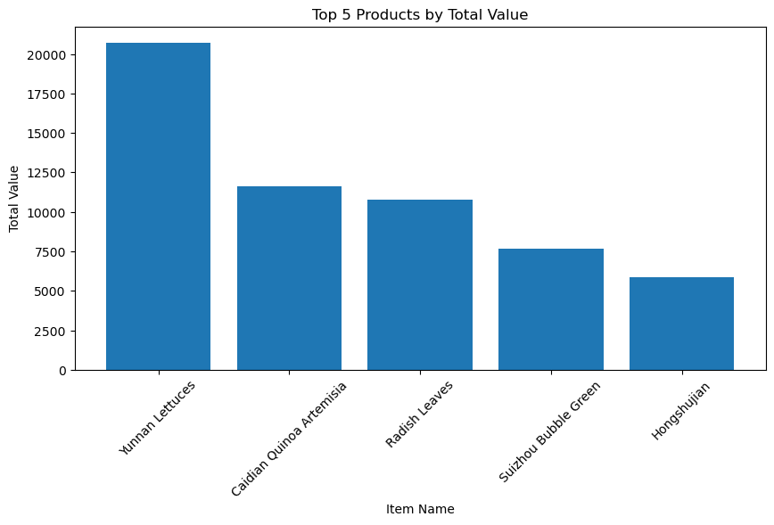

```python
# Top 5 Products Bar Chart

import matplotlib.pyplot as plt

top5 = df.sort_values(by="Total Value", ascending=False).head(5)

plt.figure(figsize=(10,5))
plt.bar(top5["Item Name"], top5["Total Value"])
plt.title("Top 5 Products by Total Value")
plt.xlabel("Item Name")
plt.ylabel("Total Value")
plt.xticks(rotation=45)
plt.show()
```

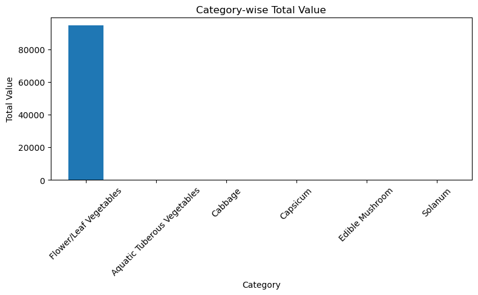

```python
# Top 5 Stock Items

category_value = df.groupby("Category Name")["Total Value"].sum().sort_values(ascending=False)

plt.figure(figsize=(8,5))
category_value.plot(kind="bar")
plt.title("Category-wise Total Value")
plt.xlabel("Category")
plt.ylabel("Total Value")
plt.xticks(rotation=45)
plt.tight_layout()
plt.show()
```

# Top 5 Products with Highest Stock

# Display the top 5 products based on available stock quantity.

```python
# Top 5 Products with Highest Stock

top_stock = df.sort_values(by="Stock in Hand", ascending=False).head(5)

top_stock
```

|  | Item Code | Item Name | Category Code | Category Name | Stock in Hand | Unit Price | Total Value |
| --- | --- | --- | --- | --- | --- | --- | --- |
| 18 | 102900005115984 | Yunnan Lettuces | 1011010101 | Flower/Leaf Vegetables | 900.0 | 23.0 | 20700.0 |
| 15 | 102900005115946 | Muercai | 1011010101 | Flower/Leaf Vegetables | 321.0 | 14.0 | 4494.0 |
| 30 | 102900011000571 | Suizhou Bubble Green | 1011010101 | Flower/Leaf Vegetables | 120.0 | 64.0 | 7680.0 |
| 10 | 102900005115854 | Radish Leaves | 1011010101 | Flower/Leaf Vegetables | 120.0 | 90.0 | 10800.0 |
| 23 | 102900005118572 | Local Shanghaiqing | 1011010101 | Flower/Leaf Vegetables | 108.0 | 54.0 | 5832.0 |

# Check the number of rows and columns in the dataset.

```python
# Dataset Shape

df.shape
```

```
(251, 7)
```

# Generate descriptive statistics for numerical columns.

```python
# Statistical Summary

df.describe()
```

|  | Item Code | Category Code | Stock in Hand | Unit Price | Total Value |
| --- | --- | --- | --- | --- | --- |
| count | 2.510000e+02 | 2.510000e+02 | 251.000000 | 251.000000 | 251.000000 |
| mean | 1.031908e+14 | 1.011010e+09 | 9.920319 | 5.183267 | 377.258964 |
| std | 1.048400e+12 | 2.915469e+02 | 62.605125 | 17.863882 | 1852.876113 |
| min | 1.029000e+14 | 1.011010e+09 | 0.000000 | 0.000000 | 0.000000 |
| 25% | 1.029000e+14 | 1.011010e+09 | 0.000000 | 0.000000 | 0.000000 |
| 50% | 1.029000e+14 | 1.011011e+09 | 0.000000 | 0.000000 | 0.000000 |
| 75% | 1.029000e+14 | 1.011011e+09 | 0.000000 | 0.000000 | 0.000000 |
| max | 1.069740e+14 | 1.011011e+09 | 900.000000 | 120.000000 | 20700.000000 |

# Display the data type of each column.

```python
# Check Data Types

df.dtypes
```

```
Item Code          int64
Item Name         object
Category Code      int64
Category Name     object
Stock in Hand    float64
Unit Price       float64
Total Value      float64
dtype: object
```

# Conclusion

This project demonstrates data cleaning, exploratory data analysis (EDA), and visualization using Python, Pandas, and Matplotlib. The analysis identified top products, inventory trends, and category-wise performance, helping derive meaningful business insights.

## Skills Used

- Python
- Pandas
- Matplotlib
- Data Cleaning
- Exploratory Data Analysis (EDA)
- Data Visualization